# A First Look at R

Joseph Rickert

March 22, 2016

## R is interpreted

R is an interpretive language. At its most basic, the console can be used as a simple calculator.

```r
2 + 2
```

```
## [1] 4
```

Putting “;” after a statement lets you put several statements on the same line.

```r
log(10); sqrt(99); sin(pi)
```

```
## [1] 2.302585
```

```
## [1] 9.949874
```

```
## [1] 1.224606e-16
```

## R was built for statistical analysis.

Here we draw 1000 numbers from a Normal (Gaussian) distribution with mean 0 and variance 1 and assign them to the vector x all in one line of code.

```r
x <- rnorm(1000)
```

Notice that nothing happened. R normally does not give you any output until you ask for it. Here are some basic ways of asking for output.

```r
head(x, 10)   # Look at the first 10 numbers in the vector x
```

```
##  [1] -2.6332896  0.4642371  0.4857188  1.2875059  0.2308080 -0.8274201
##  [7] -1.7854872  0.6351498  0.5122766 -1.2825611
```

```r
tail(x,5)     # Look at the last 5 numbers in the vector xlength(x)
```

```
## [1] -1.199133557  0.013070595 -0.008140937  0.102906295  0.894861004
```

```r
length(x)     # To check on the length of x
```

```
## [1] 1000
```

```r
summary(x)    # Get a summary of x
```

```
##      Min.   1st Qu.    Median      Mean   3rd Qu.      Max.
## -4.021000 -0.689100 -0.000375 -0.029940  0.635900  3.051000
```

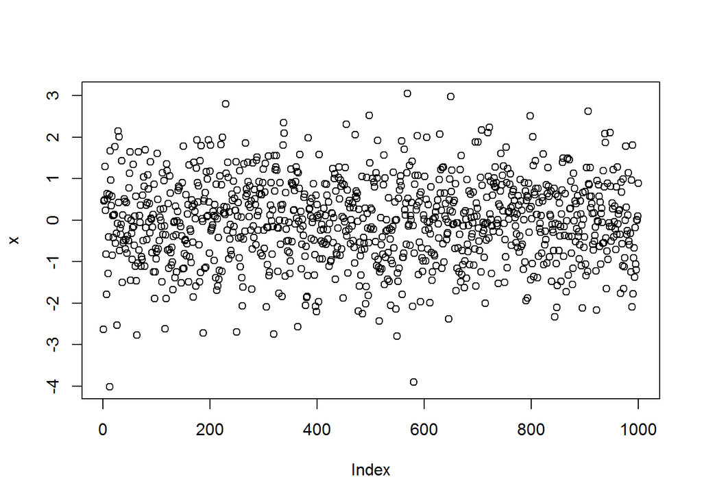

```r
plot(x)       # Produce a scatter plot of x the index (the numbers 1 to 1000)
```

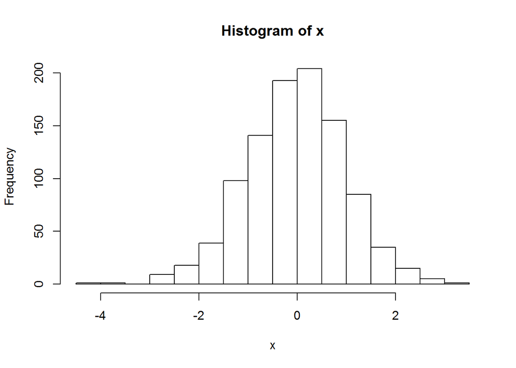

```r
hist(x)       # Look at the histogram
```

Notice that typing # is the way to introduct a comment.

Next, we produce a fancier histogram with some color, a superimposed standard normal distribution curve and a “rug” underneath showing where the points are.

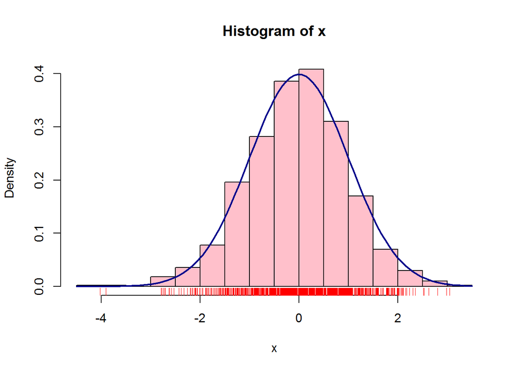

```r
hist(x, freq = FALSE, col = "pink")
curve(dnorm,                                    # plot normal density
      col = "dark blue",                        # set coor of curve
      lwd=2,                                    # fill in the area under the curve
      add = TRUE)                               # add curve to existing plot
rug(x,col="red")
```

## R is rich in built in functions.

In addition to the mathematical functions sin(), log() etc rnorm(), head(), tail(), length(), summary(), plot(), hist(), curve() are all R functions.

To get help with a function named foo, type ?foo

```r
?rnorm
```

```
## starting httpd help server ... done
```

## R is vectorized.

There is not so much of a need to write loops in R

```r
y <- 1:10         # Assign the numbers 1 to 10 to a vector
y                 # Print the vector
```

```
##  [1]  1  2  3  4  5  6  7  8  9 10
```

```r
2 + y; 2 * y      # Perform vector addition and multiplication
```

```
##  [1]  3  4  5  6  7  8  9 10 11 12
```

```
##  [1]  2  4  6  8 10 12 14 16 18 20
```

## There are lots of built in data sets in R

Type “data()” to see what data sets are available. The output which will appear under a new tab when you type this in the IDE depends on what packages you have loaded. Type data(ds_name) to load the data set. Then type ds_name to look at it

```r
data()
data(mtcars)
help(mtcars)      #  or type ?mtcars
head(mtcars)      #  to look at the first 6 rows
```

```
##                    mpg cyl disp  hp drat    wt  qsec vs am gear carb
## Mazda RX4         21.0   6  160 110 3.90 2.620 16.46  0  1    4    4
## Mazda RX4 Wag     21.0   6  160 110 3.90 2.875 17.02  0  1    4    4
## Datsun 710        22.8   4  108  93 3.85 2.320 18.61  1  1    4    1
## Hornet 4 Drive    21.4   6  258 110 3.08 3.215 19.44  1  0    3    1
## Hornet Sportabout 18.7   8  360 175 3.15 3.440 17.02  0  0    3    2
## Valiant           18.1   6  225 105 2.76 3.460 20.22  1  0    3    1
```

The fundamental data structure for doing statistical analysis is a data frame. mtcars is a data frame. You can check this with the class() function.

```r
class(mtcars)     # To check on the class of an R object
```

```
## [1] "data.frame"
```

```r
class(x)
```

```
## [1] "numeric"
```

## R shines at exploratory data analysis

Use the with() function to work with the variables in the data frame

```r
with(mtcars,cor(drat,mpg))
```

```
## [1] 0.6811719
```

```r
# There is a positive correlation beteen therear axel ratio and mpg!!
```

Use $ to refer directly to the variables in the data frame mtcars.

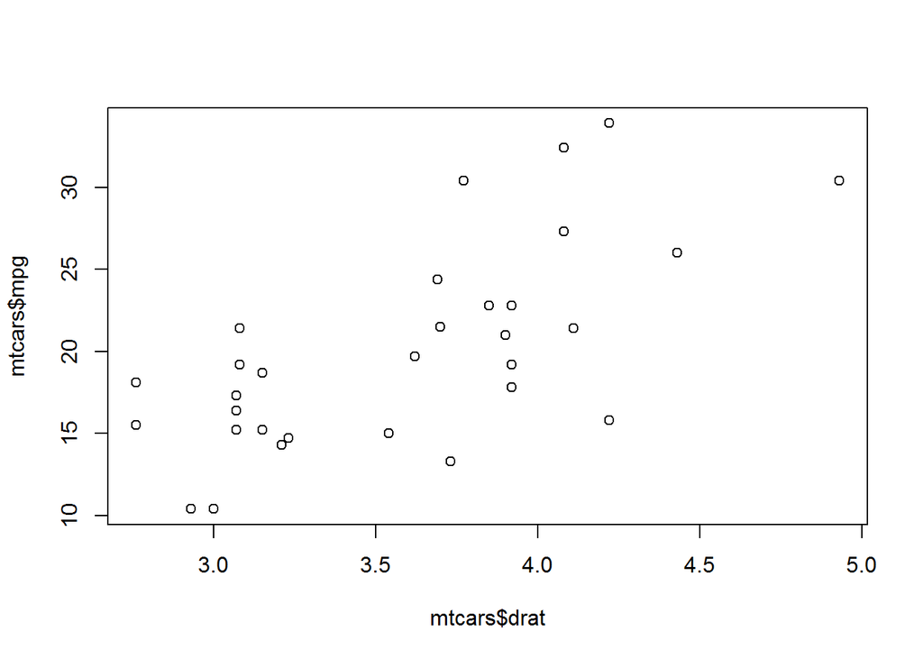

```r
plot(mtcars$drat,mtcars$mpg)
```

Notice this is the same plot function we used above for 1 variable!

## R is really vectorized

Look at all of the correlations

```r
cor(mtcars)
```

```
##             mpg        cyl       disp         hp        drat         wt
## mpg   1.0000000 -0.8521620 -0.8475514 -0.7761684  0.68117191 -0.8676594
## cyl  -0.8521620  1.0000000  0.9020329  0.8324475 -0.69993811  0.7824958
## disp -0.8475514  0.9020329  1.0000000  0.7909486 -0.71021393  0.8879799
## hp   -0.7761684  0.8324475  0.7909486  1.0000000 -0.44875912  0.6587479
## drat  0.6811719 -0.6999381 -0.7102139 -0.4487591  1.00000000 -0.7124406
## wt   -0.8676594  0.7824958  0.8879799  0.6587479 -0.71244065  1.0000000
## qsec  0.4186840 -0.5912421 -0.4336979 -0.7082234  0.09120476 -0.1747159
## vs    0.6640389 -0.8108118 -0.7104159 -0.7230967  0.44027846 -0.5549157
## am    0.5998324 -0.5226070 -0.5912270 -0.2432043  0.71271113 -0.6924953
## gear  0.4802848 -0.4926866 -0.5555692 -0.1257043  0.69961013 -0.5832870
## carb -0.5509251  0.5269883  0.3949769  0.7498125 -0.09078980  0.4276059
##             qsec         vs          am       gear        carb
## mpg   0.41868403  0.6640389  0.59983243  0.4802848 -0.55092507
## cyl  -0.59124207 -0.8108118 -0.52260705 -0.4926866  0.52698829
## disp -0.43369788 -0.7104159 -0.59122704 -0.5555692  0.39497686
## hp   -0.70822339 -0.7230967 -0.24320426 -0.1257043  0.74981247
## drat  0.09120476  0.4402785  0.71271113  0.6996101 -0.09078980
## wt   -0.17471588 -0.5549157 -0.69249526 -0.5832870  0.42760594
## qsec  1.00000000  0.7445354 -0.22986086 -0.2126822 -0.65624923
## vs    0.74453544  1.0000000  0.16834512  0.2060233 -0.56960714
## am   -0.22986086  0.1683451  1.00000000  0.7940588  0.05753435
## gear -0.21268223  0.2060233  0.79405876  1.0000000  0.27407284
## carb -0.65624923 -0.5696071  0.05753435  0.2740728  1.00000000
```

The sapply() function applies the scale() function to every column in the data frame simultaneously.

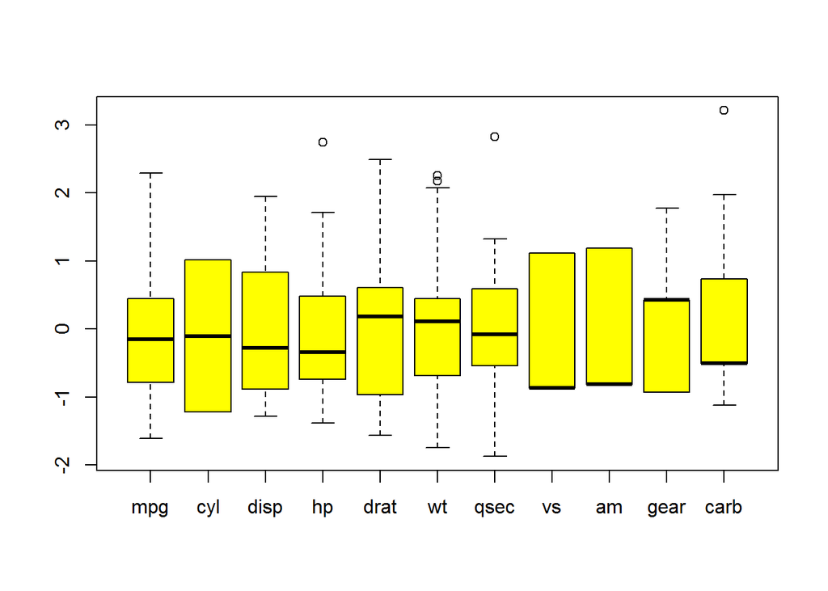

```r
df <-sapply(mtcars,scale)         # Center and scale all of the variables
boxplot(df, col="yellow")         # Compare the distributions of the variables
```

## Fit a simple regression model

```r
reg1 <- lm(mtcars$mpg ~ mtcars$drat)
summary(reg1)
```

```
##
## Call:
## lm(formula = mtcars$mpg ~ mtcars$drat)
##
## Residuals:
##     Min      1Q  Median      3Q     Max
## -9.0775 -2.6803 -0.2095  2.2976  9.0225
##
## Coefficients:
##             Estimate Std. Error t value Pr(>|t|)
## (Intercept)   -7.525      5.477  -1.374     0.18
## mtcars$drat    7.678      1.507   5.096 1.78e-05 ***
## ---
## Signif. codes:  0 '***' 0.001 '**' 0.01 '*' 0.05 '.' 0.1 ' ' 1
##
## Residual standard error: 4.485 on 30 degrees of freedom
## Multiple R-squared:  0.464,  Adjusted R-squared:  0.4461
## F-statistic: 25.97 on 1 and 30 DF,  p-value: 1.776e-05
```

```r
anova(reg1)          # Standard analysis of variance table
```

```
## Analysis of Variance Table
##
## Response: mtcars$mpg
##             Df Sum Sq Mean Sq F value    Pr(>F)
## mtcars$drat  1 522.48  522.48   25.97 1.776e-05 ***
## Residuals   30 603.57   20.12
## ---
## Signif. codes:  0 '***' 0.001 '**' 0.01 '*' 0.05 '.' 0.1 ' ' 1
```

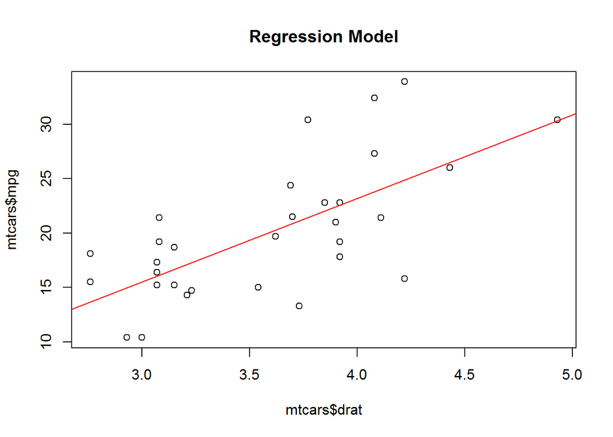

```r
# Plot the data with the regression line added
plot(mtcars$drat,mtcars$mpg, main="Regression Model")
abline(reg1,col="red")
```

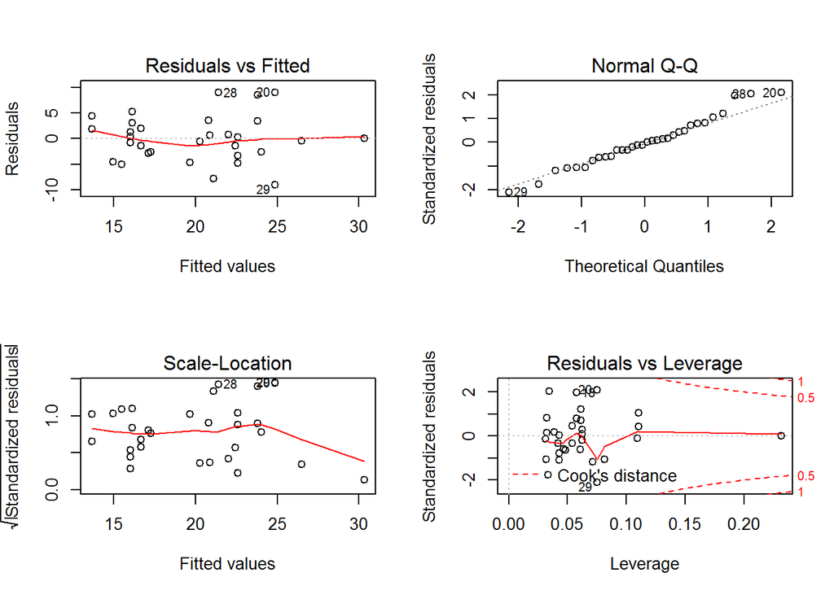

```r
par(mfrow=c(2,2))    # Some code to put the 4 plots together
plot(reg1)
```

```r
str(reg1)            # Look at the model object
```

```
## List of 12
##  $ coefficients : Named num [1:2] -7.52 7.68
##   ..- attr(*, "names")= chr [1:2] "(Intercept)" "mtcars$drat"
##  $ residuals    : Named num [1:32] -1.42 -1.42 0.763 5.276 2.038 ...
##   ..- attr(*, "names")= chr [1:32] "1" "2" "3" "4" ...
##  $ effects      : Named num [1:32] -113.65 -22.86 1.05 5.28 2.07 ...
##   ..- attr(*, "names")= chr [1:32] "(Intercept)" "mtcars$drat" "" "" ...
##  $ rank         : int 2
##  $ fitted.values: Named num [1:32] 22.4 22.4 22 16.1 16.7 ...
##   ..- attr(*, "names")= chr [1:32] "1" "2" "3" "4" ...
##  $ assign       : int [1:2] 0 1
##  $ qr           :List of 5
##   ..$ qr   : num [1:32, 1:2] -5.657 0.177 0.177 0.177 0.177 ...
##   .. ..- attr(*, "dimnames")=List of 2
##   .. .. ..$ : chr [1:32] "1" "2" "3" "4" ...
##   .. .. ..$ : chr [1:2] "(Intercept)" "mtcars$drat"
##   .. ..- attr(*, "assign")= int [1:2] 0 1
##   ..$ qraux: num [1:2] 1.18 1.09
##   ..$ pivot: int [1:2] 1 2
##   ..$ tol  : num 1e-07
##   ..$ rank : int 2
##   ..- attr(*, "class")= chr "qr"
##  $ df.residual  : int 30
##  $ xlevels      : Named list()
##  $ call         : language lm(formula = mtcars$mpg ~ mtcars$drat)
##  $ terms        :Classes 'terms', 'formula' length 3 mtcars$mpg ~ mtcars$drat
##   .. ..- attr(*, "variables")= language list(mtcars$mpg, mtcars$drat)
##   .. ..- attr(*, "factors")= int [1:2, 1] 0 1
##   .. .. ..- attr(*, "dimnames")=List of 2
##   .. .. .. ..$ : chr [1:2] "mtcars$mpg" "mtcars$drat"
##   .. .. .. ..$ : chr "mtcars$drat"
##   .. ..- attr(*, "term.labels")= chr "mtcars$drat"
##   .. ..- attr(*, "order")= int 1
##   .. ..- attr(*, "intercept")= int 1
##   .. ..- attr(*, "response")= int 1
##   .. ..- attr(*, ".Environment")=<environment: R_GlobalEnv>
##   .. ..- attr(*, "predvars")= language list(mtcars$mpg, mtcars$drat)
##   .. ..- attr(*, "dataClasses")= Named chr [1:2] "numeric" "numeric"
##   .. .. ..- attr(*, "names")= chr [1:2] "mtcars$mpg" "mtcars$drat"
##  $ model        :'data.frame':   32 obs. of  2 variables:
##   ..$ mtcars$mpg : num [1:32] 21 21 22.8 21.4 18.7 18.1 14.3 24.4 22.8 19.2 ...
##   ..$ mtcars$drat: num [1:32] 3.9 3.9 3.85 3.08 3.15 2.76 3.21 3.69 3.92 3.92 ...
##   ..- attr(*, "terms")=Classes 'terms', 'formula' length 3 mtcars$mpg ~ mtcars$drat
##   .. .. ..- attr(*, "variables")= language list(mtcars$mpg, mtcars$drat)
##   .. .. ..- attr(*, "factors")= int [1:2, 1] 0 1
##   .. .. .. ..- attr(*, "dimnames")=List of 2
##   .. .. .. .. ..$ : chr [1:2] "mtcars$mpg" "mtcars$drat"
##   .. .. .. .. ..$ : chr "mtcars$drat"
##   .. .. ..- attr(*, "term.labels")= chr "mtcars$drat"
##   .. .. ..- attr(*, "order")= int 1
##   .. .. ..- attr(*, "intercept")= int 1
##   .. .. ..- attr(*, "response")= int 1
##   .. .. ..- attr(*, ".Environment")=<environment: R_GlobalEnv>
##   .. .. ..- attr(*, "predvars")= language list(mtcars$mpg, mtcars$drat)
##   .. .. ..- attr(*, "dataClasses")= Named chr [1:2] "numeric" "numeric"
##   .. .. .. ..- attr(*, "names")= chr [1:2] "mtcars$mpg" "mtcars$drat"
##  - attr(*, "class")= chr "lm"
```

```r
reg1$coefficients    # Pull out the coefficients
```

```
## (Intercept) mtcars$drat
##   -7.524618    7.678233
```

## Clean up

```r
rm(mtcars)           # Remove mtcars
rm(list=ls())        # Remove everything: USE WITH GREAT CARE!!
```